# Intro to Data Science - HW 6

##### Copyright Jeffrey Stanton, Jeffrey Saltz, and Jasmina Tacheva

```r
# Enter your name here: Patrick Walsh
```

### Attribution statement: (choose only one and delete the rest)

```r
# 1. I did this homework by myself, with help from the book and the professor.
```

Last assignment we explored **data visualization** in R using the **ggplot2** package. This homework continues to use ggplot, but this time, with maps. In addition, we will merge datasets using the built-in **merge( )** function, which provides a similar capability to a **JOIN in SQL** (don’t worry if you do not know SQL). Many analytical strategies require joining data from different sources based on a **“key”** – a field that two datasets have in common.

## Step 1: Load the population data

1. Read the following JSON file, https://intro-datascience.s3.us-east-2.amazonaws.com/cities.json and store it in a variable called **pop**.

Examine the resulting pop dataframe and add comments explaining what each column contains.

```r
library(tidyverse)
pop <- url("https://intro-datascience.s3.us-east-2.amazonaws.com/cities.json")
pop <- jsonlite::fromJSON(pop)  # converts JSON object to R object
glimpse(pop)  # View pop dataframe with glimpse()
```

```
## Rows: 1,000
## Columns: 7
## $ city                     <chr> "New York", "Los Angeles", "Chicago", "Housto…
## $ growth_from_2000_to_2013 <chr> "4.8%", "4.8%", "-6.1%", "11.0%", "2.6%", "14…
## $ latitude                 <dbl> 40.71278, 34.05223, 41.87811, 29.76043, 39.95…
## $ longitude                <dbl> -74.00594, -118.24368, -87.62980, -95.36980, …
## $ population               <chr> "8405837", "3884307", "2718782", "2195914", "…
## $ rank                     <chr> "1", "2", "3", "4", "5", "6", "7", "8", "9", …
## $ state                    <chr> "New York", "California", "Illinois", "Texas"…
```

```r
# There are 7 columns and 1000 rows.
# 1. city = string that contains a city name
# 2. growth_from_2000_to_2013 = string that contains a percentage of growth, presumably for population
# 3. latitude = decimal number that contains the latitude of city location
# 4. longitude = decimal number that contains the longitude of city location
# 5. population = string that contains the population of the city
# 6. rank = string that contains presumably the city ranking in terms of most populated
# 7. state = string that contains the state in which the city is located
```

2. Calculate the **average population** in the dataframe. Why is using mean() directly not working? Find a way to correct the data type of this variable so you can calculate the average (and then calculate the average)

Hint: use **str(pop)** or **glimpse(pop)** to help understand the dataframe

```r
# Population is a character, so we must first convert $population to a number so that we can run quantitative
# analysis on it.
pop$population <- as.numeric(pop$population)  # convert pop$population to number
mean(pop$population)
```

```
## [1] 131132.4
```

3. What is the population of the smallest city in the dataframe? Which state is it in?

```r
which.min(pop$population)  # returns the index of the smallest population (in this case, index 1000)
```

```
## [1] 1000
```

```r
pop$state[1000]  # show the state at index 1000
```

```
## [1] "Florida"
```

```r
pop$population[1000]  # show the population at index 1000
```

```
## [1] 36877
```

## Step 2: Merge the population data with the state name data

4. Read in the state name .csv file from the URL below into a dataframe named **abbr** (for “abbreviation”) – make sure to use the read_csv() function from the tidyverse package:  
   https://intro-datascience.s3.us-east-2.amazonaws.com/statesInfo.csv

```r
abbr <- read_csv("https://intro-datascience.s3.us-east-2.amazonaws.com/statesInfo.csv")
glimpse(abbr)
```

```
## Rows: 51
## Columns: 2
## $ State        <chr> "Alabama", "Alaska", "Arizona", "Arkansas", "California",…
## $ Abbreviation <chr> "AL", "AK", "AZ", "AR", "CA", "CO", "CT", "DE", "DC", "FL…
```

5. To successfully merge the dataframe **pop** with the **abbr** dataframe, we need to identify a **column they have in common** which will serve as the **“key”** to merge on. One column both dataframes have is the **state column**. The only problem is the slight column name discrepancy – in **pop**, the column is called **“state”** and in **abbr** – **“State.”** These names need to be reconciled for the merge() function to work. Find a way to rename **abbr’s “State”** to **match** the **state column in pop**.

```r
abbr <- abbr %>% rename_at('State', ~'state')  # rename 'State' to 'state' in the abbr dataframe
```

6. Merge the two dataframes (using the **‘state’ column** from both dataframes), storing the resulting dataframe in **dfNew**.

```r
# create a new dataframe using merge() and dataframes pop and abbr. R will merge these dataframes based on existing
# columns with the same name.
dfNew <- merge(x=pop, y=abbr)
```

7. Review the structure of **dfNew** and explain the columns (aka attributes) in that dataframe.

```r
glimpse(dfNew)
```

```
## Rows: 1,000
## Columns: 8
## $ state                    <chr> "Alabama", "Alabama", "Alabama", "Alabama", "…
## $ city                     <chr> "Auburn", "Florence", "Huntsville", "Dothan",…
## $ growth_from_2000_to_2013 <chr> "26.4%", "10.2%", "16.3%", "16.6%", "-12.3%",…
## $ latitude                 <dbl> 32.60986, 34.79981, 34.73037, 31.22323, 33.52…
## $ longitude                <dbl> -85.48078, -87.67725, -86.58610, -85.39049, -…
## $ population               <dbl> 58582, 40059, 186254, 68001, 212113, 37498, 8…
## $ rank                     <chr> "615", "922", "126", "502", "101", "983", "37…
## $ Abbreviation             <chr> "AL", "AL", "AL", "AL", "AL", "AL", "AL", "AL…
```

## Step 3: Visualize the data

8. Plot points (on top of a map of the US) for **each city**. Have the **color** represent the **population**.

```r
library(ggmap)
```

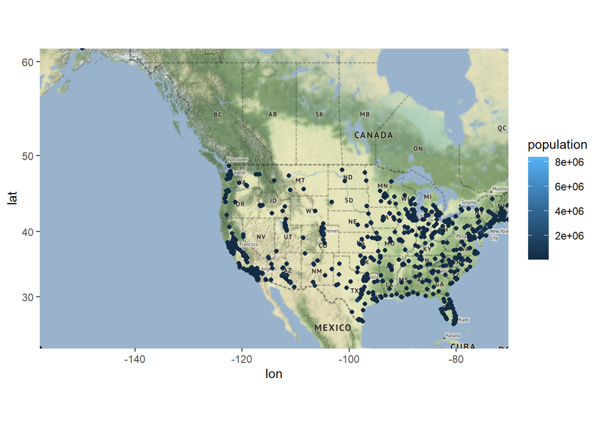

```r
bb <- c(left = min(dfNew$longitude),
        right = max(dfNew$longitude),
        bottom = min(dfNew$latitude),
        top = max(dfNew$latitude))
gmap <- get_stamenmap(bbox = bb, zoom=4, maptype="terrain")
ggmap(gmap) +
  geom_point(data=dfNew, aes(x=longitude, y=latitude, color=population))
```

1. Add a block comment that criticizes the resulting map. It’s not very good.

```r
# The color used to represent the size of the population is not very intuitive, as the shades of color are
# very similar from one population to another. It might be better to use size of the plot points to better
# visualize population sizes on the map.
```

## Step 4: Group by State

10. Use group_by and summarise to make a dataframe of state-by-state population. Store the result in **dfSimple**.

```r
library(dplyr)

dfSimple = dfNew %>% group_by(state) %>%
                    summarise(population = sum(population))
glimpse(dfSimple)
```

```
## Rows: 51
## Columns: 2
## $ state      <chr> "Alabama", "Alaska", "Arizona", "Arkansas", "California", "…
## $ population <dbl> 1279813, 300950, 4691466, 787011, 27910620, 3012284, 123981…
```

11. Name the most and least populous states in **dfSimple** and show the code you used to determine them.

```r
largest_pop <- which.max(dfSimple$population)  # get the index of the largest population and save it to variable largest_pop
dfSimple$state[largest_pop]  # display the state at the index with the largest population
```

```
## [1] "California"
```

```r
smallest_pop <- which.min(dfSimple$population)  # get the index of the smallest population and save it to variable smallest_pop
dfSimple$state[smallest_pop]  # display the state at the index with the smallest population
```

```
## [1] "Vermont"
```

## Step 5: Create a map of the U.S., with the color of the state representing the state population

12. Make sure to expand the limits correctly and that you have used **coord_map** appropriately.

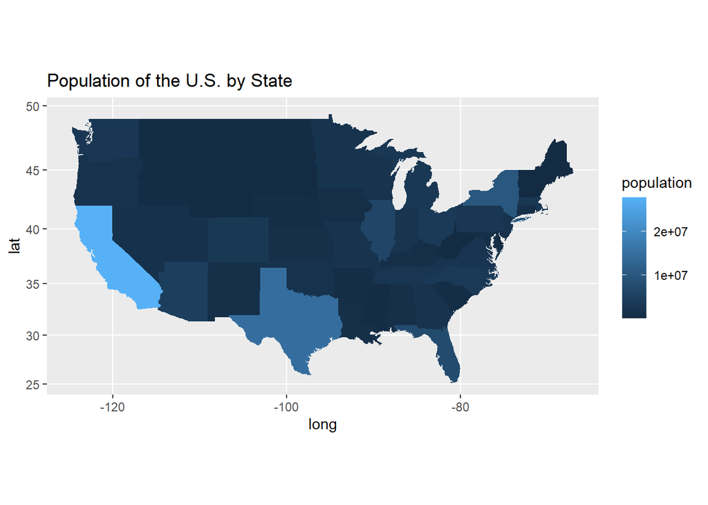

```r
dfSimple$state <- tolower(dfSimple$state)

states <- map_data("state")
mergedData <- merge(states, dfSimple, all.x=TRUE, by.x="region", by.y="state")

ggplot(mergedData)+
  geom_polygon(data=mergedData, aes(x=long,y=lat,group=group, fill=population))+
  expand_limits(x=mergedData$long, y=mergedData$lat)+
  coord_map()+
  ggtitle("Population of the U.S. by State")
```